# Student Debt

Marton Aron Varga

23 december, 2022

```r
# Or read in the data manually

lifetime_earn <- readr::read_csv('https://raw.githubusercontent.com/rfordatascience/tidytuesday/master/data/2021/2021-02-09/lifetime_earn.csv')
student_debt <- readr::read_csv('https://raw.githubusercontent.com/rfordatascience/tidytuesday/master/data/2021/2021-02-09/student_debt.csv')
retirement <- readr::read_csv('https://raw.githubusercontent.com/rfordatascience/tidytuesday/master/data/2021/2021-02-09/retirement.csv')
home_owner <- readr::read_csv('https://raw.githubusercontent.com/rfordatascience/tidytuesday/master/data/2021/2021-02-09/home_owner.csv')
race_wealth <- readr::read_csv('https://raw.githubusercontent.com/rfordatascience/tidytuesday/master/data/2021/2021-02-09/race_wealth.csv')
income_time <- readr::read_csv('https://raw.githubusercontent.com/rfordatascience/tidytuesday/master/data/2021/2021-02-09/income_time.csv')
income_limits <- readr::read_csv('https://raw.githubusercontent.com/rfordatascience/tidytuesday/master/data/2021/2021-02-09/income_limits.csv')
income_aggregate <- readr::read_csv('https://raw.githubusercontent.com/rfordatascience/tidytuesday/master/data/2021/2021-02-09/income_aggregate.csv')
income_distribution <- readr::read_csv('https://raw.githubusercontent.com/rfordatascience/tidytuesday/master/data/2021/2021-02-09/income_distribution.csv')
income_mean <- readr::read_csv('https://raw.githubusercontent.com/rfordatascience/tidytuesday/master/data/2021/2021-02-09/income_mean.csv')
```

# Introduction

# Exploratory Data Analysis

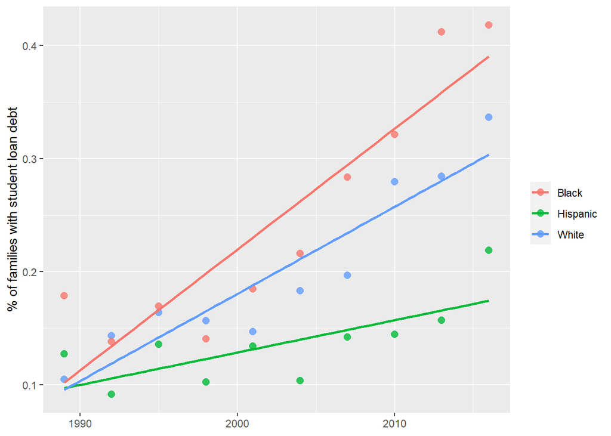

```r
student_debt %>%
  ggplot(aes(year, loan_debt_pct, color = race)) +
  geom_point(size = 2.5, alpha = 0.8) +
  geom_smooth(method = "lm", se = FALSE) +
  labs(x = NULL, y = "% of families with student loan debt", color = NULL)
```

Observe that the percentage of families with students has been substantially increasing, although at varying rates for various racial/ethnic groups.

# Model

```r
library(tidymodels)
lm_spec <-
  linear_reg() %>%
  set_engine("lm")

#Let’s fit that model to our data, using an interaction to account for how the rates/slopes have been
#hanging at different, well, rates for the different groups.

lm_fit <-
  lm_spec %>%
  fit(loan_debt_pct ~ year * race, data = student_debt)

lm_fit
```

```
## parsnip model object
##
##
## Call:
## stats::lm(formula = loan_debt_pct ~ year * race, data = data)
##
## Coefficients:
##       (Intercept)               year       raceHispanic          raceWhite
##        -21.161193           0.010690          15.563202           5.933064
## year:raceHispanic     year:raceWhite
##         -0.007827          -0.002986
```

```r
tidy(lm_fit)
```

```
## # A tibble: 6 x 5
##   term               estimate std.error statistic      p.value
##   <chr>                 <dbl>     <dbl>     <dbl>        <dbl>
## 1 (Intercept)       -21.2       2.58        -8.20 0.0000000204
## 2 year                0.0107    0.00129      8.29 0.0000000166
## 3 raceHispanic       15.6       3.65         4.26 0.000270
## 4 raceWhite           5.93      3.65         1.63 0.117
## 5 year:raceHispanic  -0.00783   0.00182     -4.29 0.000250
## 6 year:raceWhite     -0.00299   0.00182     -1.64 0.114
```

```r
new_points <- crossing(
  race = c("Black", "Hispanic", "White"),
  year = 1990:2020
)

new_points
```

```
## # A tibble: 93 x 2
##    race   year
##    <chr> <int>
##  1 Black  1990
##  2 Black  1991
##  3 Black  1992
##  4 Black  1993
##  5 Black  1994
##  6 Black  1995
##  7 Black  1996
##  8 Black  1997
##  9 Black  1998
## 10 Black  1999
## # ... with 83 more rows
```

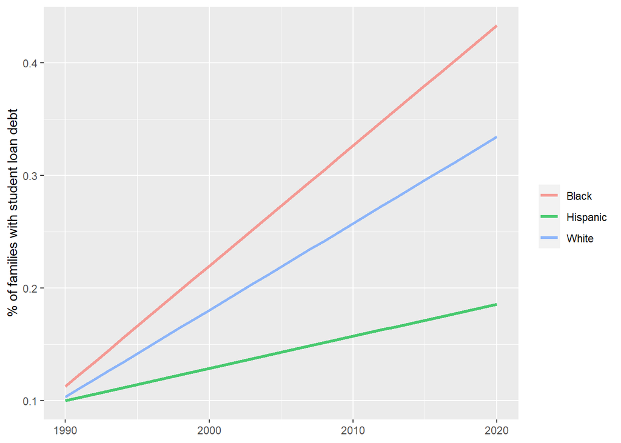

```r
augment(lm_fit, new_data = new_points) %>%
  ggplot(aes(year, .pred, color = race)) +
  geom_line(size = 1.2, alpha = 0.7) +
  labs(x = NULL, y = "% of families with student loan debt", color = NULL)
```

# Machine learning model

```r
library(caret)
set.seed(123)
split <- createDataPartition(student_debt$race, p = 0.8, list = FALSE)
train_df <- student_debt[split, ]
test_df <- student_debt[-split, ]

model <- train(loan_debt ~ race, data = train_df, method = "lm")
# Make predictions on test data
predictions <- predict(model, test_df)


# Evaluate model performance
metrics <- postResample(predictions, test_df$loan_debt)
print(metrics)
```

```
##         RMSE     Rsquared          MAE
## 1080.7684723    0.5741636  980.1371667
```

The root mean squared error (RMSE), R squared, and mean absolute error (MAE) are all measures of the performance of a machine learning model.

The RMSE is a measure of the difference between the predicted values and the actual values. It is calculated as the square root of the mean squared error, which is the average of the squared differences between the predicted values and the actual values. A lower RMSE indicates a better fit of the model to the data.

The R squared, also known as the coefficient of determination, is a measure of how well the model explains the variance in the response variable. It is calculated as the proportion of the variance in the response variable that is explained by the model. A higher R squared indicates a better fit of the model to the data.

The MAE is a measure of the average magnitude of the errors in the predictions. It is calculated as the average of the absolute differences between the predicted values and the actual values. A lower MAE indicates a better fit of the model to the data.

In this model we have predicted loan debt by race. According to the Rsquared race approx. defines 57% of the loan’s variance which is a lot!

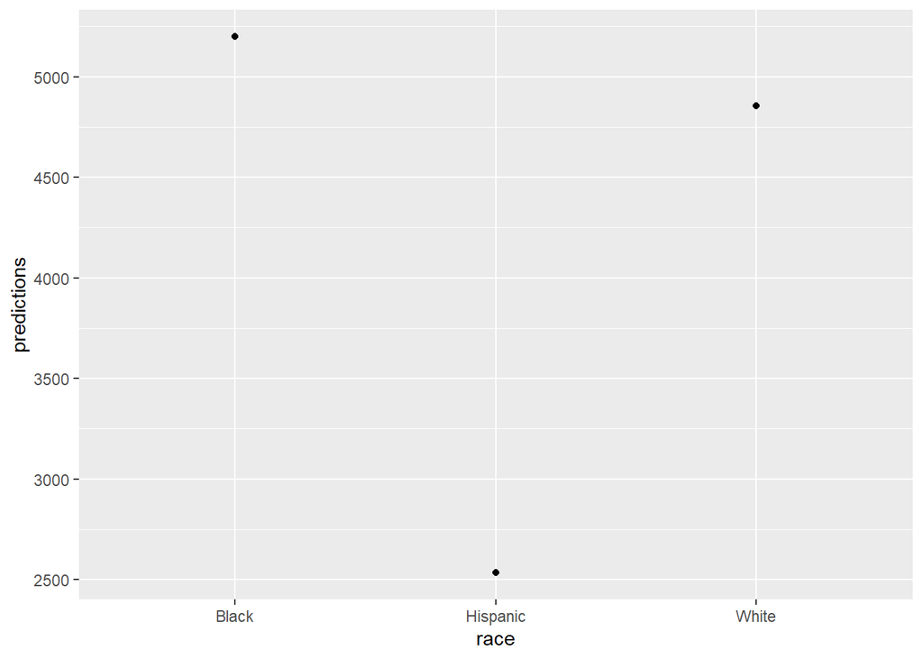

```r
# Create scatterplot of predictions vs. actual values
ggplot(test_df, aes(x = race, y = predictions)) +
  geom_point() +
  geom_abline()
```